# Программирование для анализа данных и воспроизводимые исследования. Lab 1

Илья Мусабиров, Александр Сироткин, Алёна Суворова

# План

- Регистрация
- Организация курса
- История современных языков программирования
- Трансляция. Транслятор, компилятор, интерпретатор

# Регистрация

http://vle.piterdata.ninja/groups/

# Организация курса

- *Организационные вопросы* (“Можно ли пропустить одно занятие?”, “Есть ли у нас изменения в расписании?”): ds2016@piterdata.ninja
- *Вопросы по содержанию курса* (“Так не работает!”, “Как построить гистограмму?”, “Где можно почитать дополнительно по теме X?”): qa.piterdata.ninja

**Почему именно так?**

- 197 студентов. Если у вас возник вопрос, то он возник и у кого-то еще!
- Меньше дублирующихся вопросов – больше времени на ответ – ответы лучше. Комментируйте и оценивайте!
- Хорошие вопросы и хорошие ответы – способ получить до **20% бонуса** к финальной оценке

# Про специфичность и информативность

- Формулируйте заголовок так, чтобы было понятно, о чем вопрос (заголовок “Помогите!” или “Ошибка в коде” ничем не поможет)
- Подбирайте четкие и информативные теги
  - Организационные вопросы следует сопровождать тегом `org`
  - Вопросы по расписанию - `schedule`
  - Проверить список популярных тегов может быть полезным
  - Не используем теги на кириллице
  - Стараемся по минимуму выражать свои эмоции, по типу `sad_but_true` - бесполезный тег
  - Если же вы хотите поделиться с коллегами чем-то полезным, то такие посты можно сопроводить тегами `blog`, `tutorial`, `job`, `career`, `news` etc.

# Введение в RStudio

- Панели: Source, Console, Files/Plots/Viewer
- Консоль: что это и зачем
- Работа с файлами: копирование, переименовывание, загрузка и выгрузка файлов (**NB!**: домашнее задание)
- Редактирование кода. Но сначала немного о другом…

# История современных языков программирования на одном слайде

- Эра машинного кода. Компьютеры (Computers, т.е. “Вычислители”) нужны для … вычислений. Составление программ зависит от особенностей конкретного компьютера
- Современная эра: компьютеры могут выполнять скучную монотонную работу, люди – не всегда. Так пусть они сами переводят наши пожелания в машинный код

# История современных языков программирования, ладно, на двух слайдах

> В этом новом языке [речь идет о языке COBOL] была заключена идея [Грейс] Хоппер (Grace Hopper) о том, что программы лучше писать на языке, который ближе к английскому, нежели на языке, который ближе к машинному коду (как, напр., ассемблер). COBOL стал наиболее распространённым языком для бизнес-приложений и остаётся таковым по сей день. (Wikipedia)

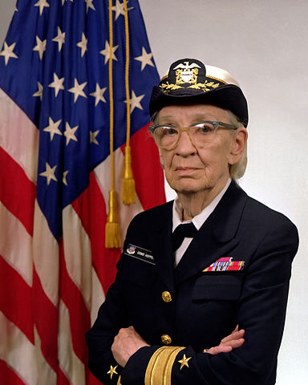

# Что такое трансляция (translation)?

- Предположения?
- Трансляция vs. Интрепретация

# Транслятор. Определения

**Транслятор** – система, выполняющее преобразование с одного из языков в другой язык с сохранением смысла

**Компилятор** – система, выполняющая преобразование программы, представленной на одном из языков программирования, в программу на другом языке (обычно в машинный код)

**Интерпретатор** – система, выполняющая анализ отдельного объекта на входном языке с одновременным выполнением (интерпретацией)

# Компилятор

- Аналогия: **перевод** документа целиком (включая структуру, оформление, и т.д.)
- Действия: компилятор преобразует программы в машинный код, соответсвующий конкретной архитектуре процессора (=можно писать на одном языке для разных типов архитектуры)
- Примеры компилируемых языков: C, C++, Fortran, …
- Достоинства:
  - высокая скорость
  - выполнения не зависит от элементов исходного языка
- Недостатки:
  - более длинный цикл разработки

# Интерпретатор

- Аналогия: говоря об интерпретации мы имеем в виду …

# Интерпретатор

- Аналогия: говоря об интерпретации мы имеем в виду **диалог**
- Действия: анализирует и тут же выполняет программу покомандно, **одну за одной**, по мере поступления ее исходного кода на вход интерпретатора
- Примеры интерпретируемых языков: R, Python, PHP …
- Достоинства:
  - Более высокая скорость разработки
  - Возможность интерактивной работы
- Недостатки:
  - Низкая скорость работы
  - Более высокие требования к ресурсам (например, к памяти)

# Интерпретация: R

[interactive chart not shown]

# Языки разметки

- Что такое язык разметки (mark-up language)?
- И зачем они нужны?

# RMarkdown и HTML

- `~/shared/minor2_2016/lab01/profile.Rmd` - перед началом работы сохраните к себе
- Как это работает?

[interactive chart not shown]

# Задание: расскажите о себе (создание собственного профиля)

- Используйте пример
- Markdown это просто. Где можно найти ответы на вопросы?
  - [Шпаргалка от RStudio](https://www.rstudio.com/wp-content/uploads/2015/02/rmarkdown-cheatsheet.pdf)
  - [и расширенная версия](https://www.rstudio.com/wp-content/uploads/2015/03/rmarkdown-reference.pdf)